# corncob for gene abundance from shotgun data

Bryan D Martin, Taylor Reiter, Pauline Trinh, Amy Willis

```r
library(readr)
library(phyloseq)
library(dplyr)
library(corncob)
library(ggplot2)
```

This tutorial is based on the data from [these slides](https://github.com/statdivlab/stamps2019/blob/master/estimation/estimation-lecture.pdf) (roughly slides 63 - 68).

## Creating a phyloseq object

First, let’s take the raw data and transform it into `phyloseq` objects. This isn’t strictly necessary for using `corncob` (we can also just use `data.frame` or `matrix` objects), but it will allow us to generalize our workflow as much as possible and create data in the nice `phyloseq` form. First, we’ll load the data.

```r
download.file("https://raw.githubusercontent.com/statdivlab/stamps2019/master/labs/data/count_data.csv", "count_data.csv")
count_data <- read_csv("./count_data.csv")

download.file("https://raw.githubusercontent.com/statdivlab/stamps2019/master/labs/data/sample_data.csv", "sample_data.csv")
sample_data <- read_csv("./sample_data.csv")
```

Next, let’s look at the data to make sure it is in the format we want.

```r
# View the data, in console
# count_data
```

We can see that the first column is actually the names, not count data. Further, the “taxa” (in this case, the genes) are the rows. So to extract the actually count data, we will remove the first column, use `dplyr::pull` to extract it and store it as the `taxa_names` for our object.

```r
# remove the first column, set taxa as rows
my_counts <- otu_table(count_data[,-1], taxa_are_rows = TRUE)
# Pull out the gene ID to use as "taxa" names
taxa_names(my_counts) <- count_data %>% pull(X1)
```

Now let’s go through the same process for the sample data. This time, the extra column represents the `sample_names`. We’ll make sure to distinguish this from `taxa_names` when creating our object.

```r
# View the data, in console
# sample_data
```

While we could trim a lot of information here for the purposes of this tutorial, let’s just pretend we only want to get rid of some of the identification variables. In this case, we will remove the first three columns, and store the second column as our `sample_names`.

```r
# Remove first three columns
my_samp <- sample_data(sample_data[,-c(1:3)])
# Pull out the sample ID to use as sample names
# Note that I have to use the original data,
# as I removed this column from my_samp
sample_names(my_samp) <- sample_data %>% pull(sampleID)
```

Now, to create a basic `phyloseq` object, we just tell it to combine these objects. `phyloseq` will automatically make sure that our sample names and taxa names match, so if we have an extra row or column and the data sets aren’t trivially combined, it will warn us. This can be a pain, but it is much, much better than accidentally using data that doesn’t represent what we think it does.

```r
mahery <- phyloseq(my_counts, my_samp)
mahery
```

```
## phyloseq-class experiment-level object
## otu_table()   OTU Table:         [ 8593 taxa and 110 samples ]
## sample_data() Sample Data:       [ 110 samples by 28 sample variables ]
```

## Using corncob

```r
my_output <- differentialTest(formula = ~ Sex*BMI,
                              formula_null = ~ Sex,
                              phi.formula = ~ 1,
                              phi.formula_null = ~ 1,
                              data = mahery,
                              test = "Wald", boot = FALSE)
```

Let’s investigate the significant genes.

```r
my_output$significant_taxa
```

```
## [1] "A47_02_1FE__bin.11_00187"
```

In this case, we only have one. That’s fine! Let’s plot the data for this gene, ordered by BMI.

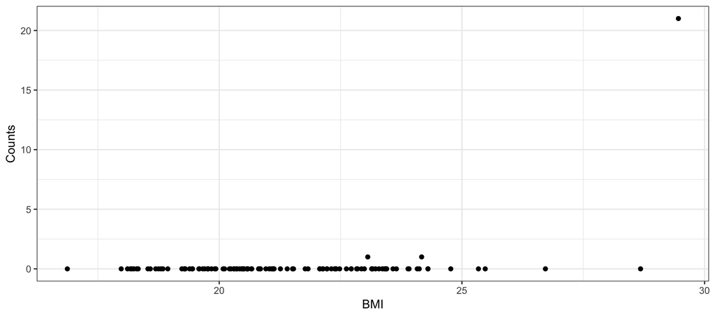

```r
# subset the gene counts
all_counts <- as.matrix(phyloseq::otu_table(mahery)@.Data)
my_gene_counts <- all_counts["A47_02_1FE__bin.11_00187",]
# subset the BMI data
all_samp <- as.data.frame(phyloseq::sample_data(mahery))
my_BMI <- all_samp$BMI
my_gene <- data.frame(cbind(Counts = my_gene_counts,
                            BMI = my_BMI,
                            Sample_ID = 1:110))
ggplot(my_gene, aes(x = BMI, y = Counts)) +
  geom_point() +
  theme_bw()
```

Here, we can see that we have only three non-zero counts, all at above average BMI. In this case, we have an outlier, which also happens to be the sample in which we observed a high count for this gene. Thus, in this case, we probably wouldn’t (and shouldn’t) consider it biologically useful. Thus, for this data set, we might conclude that BMI doesn’t explain gene abundances.

So, perhaps there is nothing to see here! However, this matches what we know about the human gut microbiome. Diet is a major driver of composition of the human gut microbiome [1]. Diet is such a strong predictor of gut microbiome composition that it has been demonstrated that it shapes similar microbiomes across mammalian lineages [2].

The population that we studied here is local people in rainforested areas of north-eastern Madagascar (near the city of Maroantsetra) with a very unique diet. The population is nearly a fully autarchic food production system. They hunt and gather wild harvest foods that the forests and rivers provide, as well as practice agriculture for rice production. Wild meats they consume include lemurs, bats, carnivores, tenrecs. Because market access is nearly non-existent and domesticated meats are a rare luxury in this region, wild meats provide crucial micronutrients that are otherwise unavailable in the diet.

### Citations

[[1]](https://www.nature.com/articles/nature12820?ref=vc.ru)

[[2]](https://science.sciencemag.org/content/332/6032/970)

[cohort paper](https://academic.oup.com/ije/article/46/6/1747/3868352)